# **Google Data Analytics Course Capstone**

## Case Study: How Does a Bike-Share Navigate Speedy Success?

## Ask Phase

#### **Background info**

- You are a junior data analyst working in the marketing analyst team at *Cyclistic*, a bike-share company in Chicago. In 2016, *Cyclistic* launched a successful bike-share offering. Since then, the program has grown to a fleet of 5,824 bicycles that are geotracked and locked into a network of 692 stations across Chicago. The bikes can be unlocked from one station and returned to any other station in the system anytime.
- Until now, *Cyclistic*’s marketing strategy relied on building general awareness and appealing to broad consumer segments. One approach that helped make these things possible was the flexibility of its pricing plans: single-ride passes, full-day passes, and annual memberships. Customers who purchase single-ride or full-day passes are referred to as casual riders. Customers who purchase annual memberships are *Cyclistic* members. *Cyclistic*’s finance analysts have concluded that annual members are much more profitable than casual riders. Although the pricing flexibility helps *Cyclistic* attract more customers, Moreno believes that maximizing the number of annual members will be key to future growth. Rather than creating a marketing campaign that targets all-new customers, Moreno believes there is a very good chance to convert casual riders into members. She notes that casual riders are already aware of the *Cyclistic* program and have chosen *Cyclistic* for their mobility needs.
- The aim is to design marketing strategies aimed at converting casual riders into annual members. In order to do that, however, the marketing analyst team needs to better understand how annual members and casual riders differ, why casual riders would buy a membership, and how digital media could affect their marketing tactics. Moreno and her team are interested in analyzing the *Cyclistic* historical bike trip data to identify trends. **Your task is to understand the difference between casual and annual members.**

#### **Key stakeholders**

- **Lily Moreno:** The director of marketing and your manager. Moreno is responsible for the development of campaigns and initiatives to promote the bike-share program. These may include email, social media, and other channels.
- *Cyclistic* marketing analytics team: A team of data analysts who are responsible for collecting, analyzing, and reporting data that helps guide *Cyclistic* marketing strategy. You joined this team six months ago and have been busy learning about *Cyclistic*’s mission and business goals — as well as how you, as a junior data analyst, can help *Cyclistic* achieve them.
- *Cyclistic* executive team: The notoriously detail-oriented executive team will decide whether to approve the recommended marketing program.

#### **Deliverables**

- A clear statement of the business task
- A description of all data sources used
- Documentation of any cleaning or manipulation of data
- A summary of the analysis
- Supporting visualizations and key findings
- Recommendations based on the analysis

#### **Business task**

The goal is to **find the difference between annual members and casual riders use of *Cyclistic* bikes**

#### **Data Source**

- Last 12 months of *Cyclistic*’s historical trips database: *Index of bucket “divvy-tripdata”*. Here’s the [link](https://divvy-tripdata.s3.amazonaws.com/index.html)

## Prepare Phase

#### **About the data source**

##### Does the data **ROCCC**?

```r
setwd("C:/Users/Marcos/Desktop/trip-data")

  library(tidyverse)
  library(lubridate)
  library(janitor)
  library(knitr)
  library(ggplot2)

  a <- read_csv("202109-divvy-tripdata.csv")
  b <- read_csv("202110-divvy-tripdata.csv")
  c <- read_csv("202111-divvy-tripdata.csv")
  d <- read_csv("202112-divvy-tripdata.csv")
  e <- read_csv("202201-divvy-tripdata.csv")
  f <- read_csv("202201-divvy-tripdata.csv")
  g <- read_csv("202201-divvy-tripdata.csv")
  h <- read_csv("202201-divvy-tripdata.csv")
  i <- read_csv("202201-divvy-tripdata.csv")
  j <- read_csv("202201-divvy-tripdata.csv")
  k <- read_csv("202201-divvy-tripdata.csv")
  l <- read_csv("202201-divvy-tripdata.csv")

  trips_data <- rbind(a,b,c,d,e,f,g,h,i,j,k,l)
  sample_trips_data <- sample_n(trips_data,500000)
  rm(trips_data,a,b,c,d,e,f,g,h,i,j,k,l)
```

## Cleaning Phase

#### **Cleaning and Manipulation**

Let’s start cleaning and checking for errors.

```r
  rename_with(sample_trips_data,tolower)
  clean_names(sample_trips_data)
```

```r
sapply(sample_trips_data, function(x) sum(is.na(x)))
```

```
##            ride_id      rideable_type         started_at           ended_at
##                  0                  0                  0                  0
## start_station_name   start_station_id   end_station_name     end_station_id
##              80674              80674              86234              86234
##          start_lat          start_lng            end_lat            end_lng
##                  0                  0                385                385
##      member_casual
##                  0
```

Now we check if all the columns data types are correct

```r
glimpse(sample_trips_data)
```

```
## Rows: 500,000
## Columns: 13
## $ ride_id            <chr> "E1B2D3565BA38069", "5456CA0BA268BD02", "D0F000627A…
## $ rideable_type      <chr> "classic_bike", "classic_bike", "classic_bike", "el…
## $ started_at         <dttm> 2021-10-09 12:24:04, 2022-01-26 07:53:38, 2022-01-…
## $ ended_at           <dttm> 2021-10-09 13:19:45, 2022-01-26 08:13:36, 2022-01-…
## $ start_station_name <chr> "University Ave & 57th St", "Ashland Ave & Augusta …
## $ start_station_id   <chr> "KA1503000071", "13248", "RN-", "KA1504000133", "13…
## $ end_station_name   <chr> "DuSable Lake Shore Dr & Monroe St", "Wolcott Ave &…
## $ end_station_id     <chr> "13300", "TA1309000064", "KA1504000135", "637", "13…
## $ start_lat          <dbl> 41.79148, 41.89964, 41.89102, 41.90251, 41.86927, 4…
## $ start_lng          <dbl> -87.59986, -87.66770, -87.63548, -87.62778, -87.673…
## $ end_lat            <dbl> 41.88096, 41.87126, 41.90322, 41.89563, 41.87725, 4…
## $ end_lng            <dbl> -87.61674, -87.67369, -87.63432, -87.67207, -87.639…
## $ member_casual      <chr> "casual", "member", "member", "member", "member", "…
```

Everything seems good meaning we can start analyzing.

## Analyze phase

#### **A summary of my analysis**

For my analysis, I focused on the trip duration, the difference in bike usage, the use depending on the day and on each hour of the day and the geography of each trip.

The first thing I did is to calculate the time difference between the start of the trip and the end.

```r
#Let's create a new row with the trip length in minutes

sample_trips_data$trip_duration_in_mins <- difftime(sample_trips_data$ended_at,sample_trips_data$started_at, units = "mins")
sample_trips_data$trip_duration_in_mins <- round(sample_trips_data$trip_duration_in_mins, digits = 0)


kable(head(sort(sample_trips_data$trip_duration_in_mins*-1)*-1),decreasing = TRUE, format = "markdown")
```

| x |
| --- |
| 40705 mins |
| 32859 mins |
| 29271 mins |
| 26439 mins |
| 26439 mins |
| 26439 mins |

-Some of the trips are very long and make the data biases. Let’s leave them out and focus on trips smaller than 120 minutes. We then create the data frame.

```r
# We remove trips longer than 2 hours and then create the df.

duration_trips_data <- sample_trips_data %>%
  filter(trip_duration_in_mins < 120)

a <- duration_trips_data %>%
  select(member_casual,trip_duration_in_mins) %>%
  group_by(member_casual) %>%
  summarise(avg_duration = round(mean(trip_duration_in_mins), digits = 0))

b <- duration_trips_data %>%
  select(member_casual,trip_duration_in_mins) %>%
  group_by(member_casual) %>%
  count(member_casual) %>%
  rename(amount = n)

member_casual_vs_durationdf <-  inner_join(b,a, by = "member_casual")


kable(head(member_casual_vs_durationdf[,1:3]), format = "markdown")
```

| member_casual | amount | avg_duration |
| --- | --- | --- |
| casual | 164456 | 19 mins |
| member | 331879 | 11 mins |

**Notes**:  
- Members tend to do 42% shorter trips in average than a casual user.

Let’s keep digging in order to create a scatter plot.

```r
# You will understand the reason of this chunck once you see the chart.
# We remove stations with less than 7 trips to not make it biased.


a <- duration_trips_data %>%
  select(start_station_name,trip_duration_in_mins) %>%
  group_by(start_station_name) %>%
  summarise(avg_duration = mean(trip_duration_in_mins)) %>%
  arrange(avg_duration*-1)

b <- duration_trips_data %>%
  select(start_station_name,trip_duration_in_mins,member_casual) %>%
  group_by(start_station_name) %>%
  count(start_station_name) %>%
  rename(amount = n)

c <- duration_trips_data %>%
  select(start_station_name,member_casual) %>%
  filter(member_casual == "member") %>%
  group_by(start_station_name) %>%
  count(member_casual)

duration_vs_station <- inner_join(b,inner_join(c,a,by = "start_station_name"), by = "start_station_name")
duration_vs_station$percentage_of_members <- (duration_vs_station$n*100)/duration_vs_station$amount

duration_vs_station <- duration_vs_station %>%
  arrange(avg_duration*-1) %>%
  filter(n > 50)

kable(head(duration_vs_station[,1:6]), format = "markdown")
```

| start_station_name | amount | member_casual | n | avg_duration | percentage_of_members |
| --- | --- | --- | --- | --- | --- |
| South Shore Dr & 71st St | 96 | member | 62 | 34.95833 mins | 64.58333 |
| DuSable Lake Shore Dr & Monroe St | 2318 | member | 621 | 30.68292 mins | 26.79034 |
| Museum of Science and Industry | 346 | member | 180 | 30.47688 mins | 52.02312 |
| Fort Dearborn Dr & 31st St | 467 | member | 293 | 29.94004 mins | 62.74090 |
| Buckingham Fountain | 519 | member | 86 | 29.15029 mins | 16.57033 |
| Streeter Dr & Grand Ave | 3937 | member | 972 | 28.80747 mins | 24.68885 |

-We now analyze which type of bike each type of user uses the most.

```r
casual_vs_members_rideabletype <- sample_trips_data %>%
  select(rideable_type,member_casual) %>%
  group_by(rideable_type) %>%
  count(member_casual) %>%
  mutate(percentage = (n * 100)/ 500000) %>%
  rename(amount = n)

amount_of_members = 331422
amount_of_casuals = 164849

rideabletype_members <- casual_vs_members_rideabletype %>%
  filter(member_casual == "member") %>%
  mutate(percentage = (amount * 100)/ amount_of_members) %>%
  arrange(percentage*-1)

rideabletype_casuals <- casual_vs_members_rideabletype %>%
  filter(member_casual == "casual") %>%
  mutate(percentage = (amount * 100)/ amount_of_casuals) %>%
  arrange(percentage*-1)

kable(head(rideabletype_members[,1:4]), format = "markdown")
```

| rideable_type | member_casual | amount | percentage |
| --- | --- | --- | --- |
| classic_bike | member | 188871 | 56.98807 |
| electric_bike | member | 143856 | 43.40569 |

```r
kable(head(rideabletype_casuals[,1:4]), format = "markdown")
```

| rideable_type | member_casual | amount | percentage |
| --- | --- | --- | --- |
| electric_bike | casual | 81096 | 49.194111 |
| classic_bike | casual | 72384 | 43.909275 |
| docked_bike | casual | 13793 | 8.367051 |

**Notes**:  
Members prefer classic bikes while casuals prefer electric bikes.

-The next step is to check in which days of the week each user are more active.

```r
# The variation in the weekly basis use of each type of user.

sample_trips_data$day_of_the_week <- wday(sample_trips_data$started_at, week_start=1)

days_of_the_Week <- list("Monday","Tuesday","Wednesday","Thursday","Friday","Saturday","Sunday")
weekly_members_use <-  sample_trips_data %>%
  select(member_casual,day_of_the_week) %>%
  filter(member_casual == "member") %>%
  group_by(day_of_the_week) %>%
  count(member_casual) %>%
  rename(amount = n) %>%
  mutate(percentage = (amount*100)/amount_of_members) %>%
  arrange(day_of_the_week)
weekly_members_use$day <- c("Monday","Tuesday","Wednesday","Thursday","Friday","Saturday","Sunday")

weekly_casuals_use <-  sample_trips_data %>%
  select(member_casual,day_of_the_week) %>%
  filter(member_casual == "casual") %>%
  group_by(day_of_the_week) %>%
  count(member_casual) %>%
  rename(amount = n) %>%
  mutate(percentage = (amount*100)/amount_of_casuals)
weekly_casuals_use$day <- c("Monday","Tuesday","Wednesday","Thursday","Friday","Saturday","Sunday")

kable(head(weekly_members_use[,1:5]), format = "markdown")
```

| day_of_the_week | member_casual | amount | percentage | day |
| --- | --- | --- | --- | --- |
| 1 | member | 46831 | 14.13032 | Monday |
| 2 | member | 51624 | 15.57652 | Tuesday |
| 3 | member | 53976 | 16.28618 | Wednesday |
| 4 | member | 52670 | 15.89213 | Thursday |
| 5 | member | 46678 | 14.08416 | Friday |
| 6 | member | 43979 | 13.26979 | Saturday |

```r
kable(head(weekly_casuals_use[,1:5]), format = "markdown")
```

| day_of_the_week | member_casual | amount | percentage | day |
| --- | --- | --- | --- | --- |
| 1 | casual | 18985 | 11.51660 | Monday |
| 2 | casual | 17697 | 10.73528 | Tuesday |
| 3 | casual | 20453 | 12.40711 | Wednesday |
| 4 | casual | 20591 | 12.49082 | Thursday |
| 5 | casual | 23937 | 14.52056 | Friday |
| 6 | casual | 36101 | 21.89944 | Saturday |

**Notes:**  
- Casuals are more active in weekends and members are evenly distributed throughout the week.

-We proceed to analyze in which hours members and casuals use Cyclistic bikes the most.

```r
sample_trips_data$hour <- format(as.POSIXct(sample_trips_data$started_at), format = "%H")

daily_members_use <-  sample_trips_data %>%
  select(member_casual,hour) %>%
  filter(member_casual == "member") %>%
  group_by(hour) %>%
  count(member_casual) %>%
  rename(amount = n) %>%
  mutate(percentage = (amount*100)/amount_of_members) %>%
  arrange(percentage*-1)

daily_casuals_use <-  sample_trips_data %>%
  select(member_casual,hour) %>%
  filter(member_casual == "casual") %>%
  group_by(hour) %>%
  count(member_casual) %>%
  rename(amount = n) %>%
  mutate(percentage = (amount*100)/amount_of_casuals) %>%
  arrange(percentage*-1)



kable(head(daily_members_use[,1:4]), format = "markdown")
```

| hour | member_casual | amount | percentage |
| --- | --- | --- | --- |
| 17 | member | 33925 | 10.236194 |
| 16 | member | 29407 | 8.872978 |
| 18 | member | 26815 | 8.090893 |
| 15 | member | 23341 | 7.042683 |
| 08 | member | 20886 | 6.301935 |
| 12 | member | 20158 | 6.082276 |

```r
kable(head(daily_casuals_use[,1:4]), format = "markdown")
```

| hour | member_casual | amount | percentage |
| --- | --- | --- | --- |
| 17 | casual | 14893 | 9.034328 |
| 16 | casual | 13741 | 8.335507 |
| 18 | casual | 13292 | 8.063137 |
| 15 | casual | 12912 | 7.832623 |
| 14 | casual | 11945 | 7.246025 |
| 13 | casual | 11417 | 6.925732 |

## Visualization phase

#### **R**

##### The relationship between a trip duration and the likelihood of being a member.

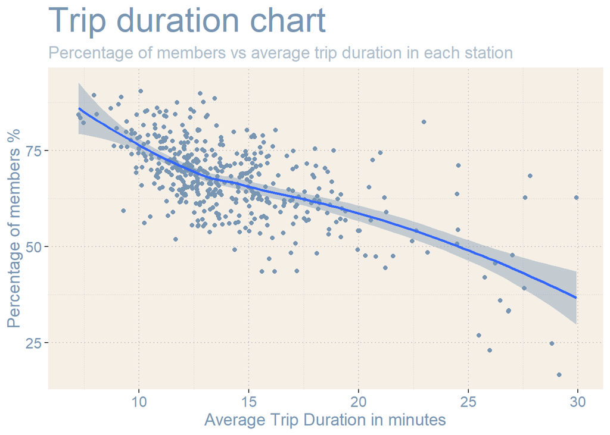

```r
ggplot(duration_vs_station, aes(x=avg_duration, y=percentage_of_members)) +
  geom_point(color="#7895B2") +
  geom_smooth(fill = "#7895B2") +
  xlab("Average Trip Duration in minutes") +
  ylab("Percentage of members %") +
  labs(title = "Trip duration chart", subtitle = "Percentage of members vs average trip duration in each station") +
  theme(axis.title = element_text(color = "#7895B2",size = 14),
        plot.title = element_text(size = 28, color = "#7895B2"),
        plot.subtitle = element_text(size = 14, color = "#AEBDCA"),
        axis.text = element_text(color = "#7895B2",size = 12),
        panel.background = element_rect(fill = "#F5EFE6"),
        panel.grid = element_line(color = 'grey', linetype = 'dotted')
  ) +
  xlim(7, 30)
```

The longer the trip, the lower the percentage of members will be.

```r
# We calculate the correlation coefficient between the two vectors.

print(cor(as.numeric(duration_vs_station$avg_duration),duration_vs_station$percentage_of_members))
```

```
## [1] -0.6312793
```

-**Result: Moderate correlation**

#### **Tableau**

You can click this **[link](https://public.tableau.com/app/profile/marcos.gahan)** to see all the interactive charts.

##### **In which places each type of user is more frequent?** - [Tableau link](https://public.tableau.com/app/profile/marcos.gahan/viz/GeographicdistributionofCyclisitcusers/Sheet1)

[figure not shown]

-Casual trips are more focused on the tourist side of the city while member in the business side.

##### **Weekly distribution** - [Tableau link](https://public.tableau.com/app/profile/marcos.gahan/viz/Cyclistic-Weeklydistribution/Dashboard1)

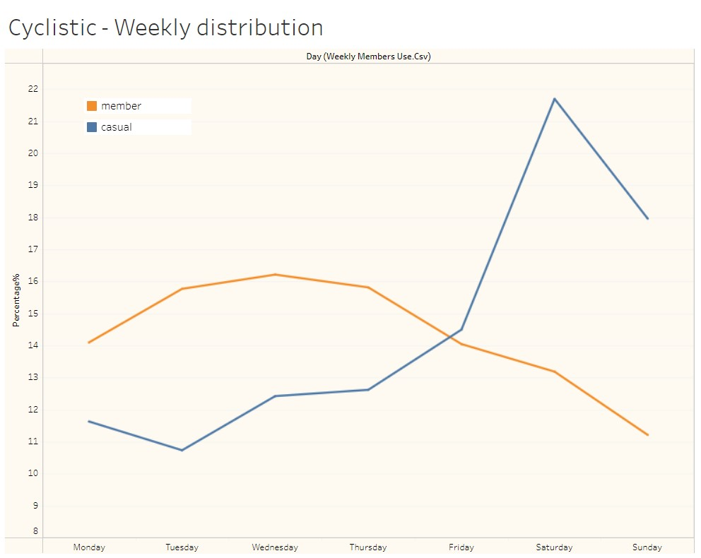

Casual trips increase on weekends while member trips are evenly distributed throughout the laboral and decrease on weekends.

##### **Daily distribution** - [Tableau link](https://public.tableau.com/app/profile/marcos.gahan/viz/Cyclistic-DailyDistribution/Dashboard1)

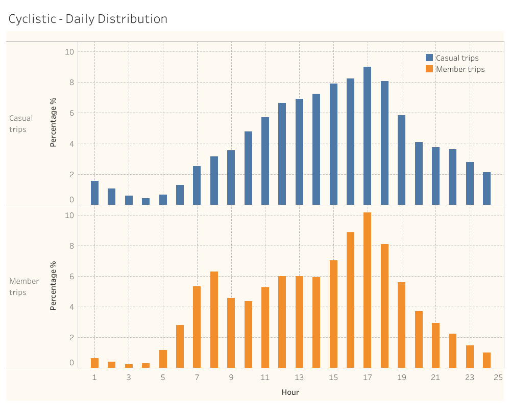

- Members usage increase at the beggining and ending of working hours (8am-5pm).

##### **Rideable type** - [Tableau link](https://public.tableau.com/app/profile/marcos.gahan/viz/Cyclistic-Rideabletype/Dashboard1)

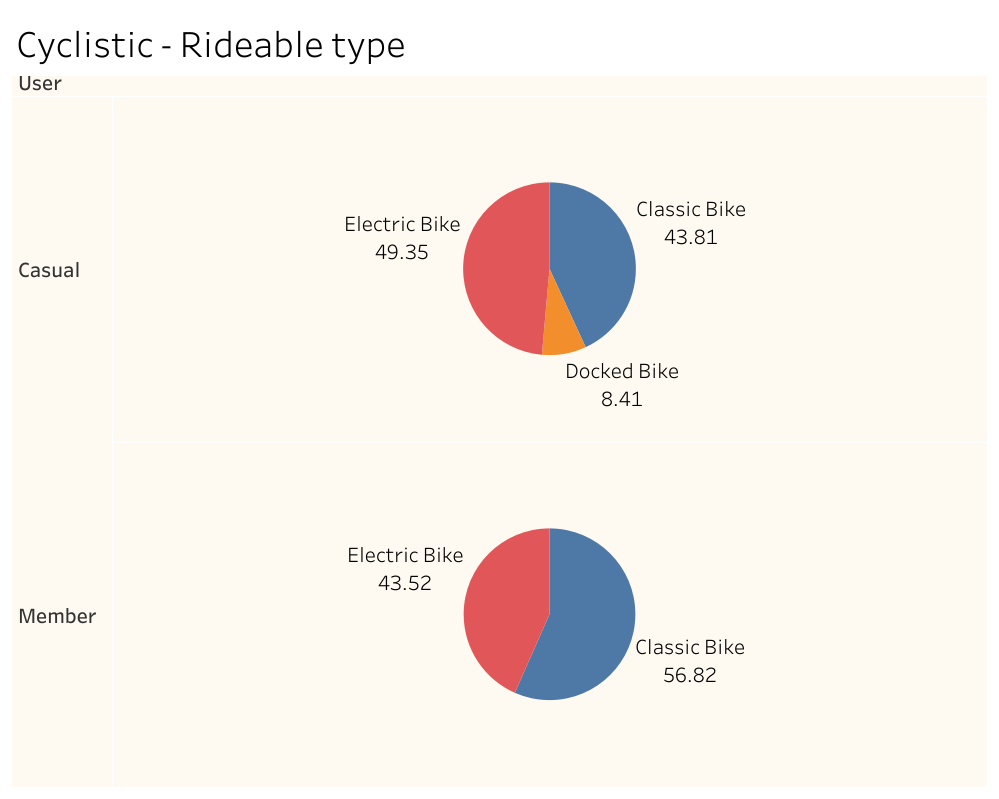

- There are no significant differences but members use Classic Bikes a 13% more than casuals.

## Act phase

### Findings

- Members tend to do shorter trips.
- Casual trips are more focused on the tourist side of the city while member in the business side.
- Casual trips increase on weekends while member trips are evenly distributed throughout the work days and decrease on weekends.
- Members usage increase at the beggining and ending of working hours (8am-5pm).
- There are no significant differences in the rideable type preferences but members use classic bikes 13% more than casuals.  
  **Key finding:** Casual riders mostly use bikes for recreational purposes while members to go to their jobs. It may be very difficult to turn a casual user to member if the reason of the trip is recreational (which are concentrated on the tourist side of cities).

### Recommendations

-Focus more marketing campaigns on the business side of the city, where casuals are more likely to turn into members.

-Users who frequent touristic zones may be more interested in a Weekend subscription.

-Offer discounts or benefits on Monday to Friday trips to attract users who make casual trips to go work.